# STA207 Hw4 - Eric Kalosa-Kenyon

```r
library("additivityTests")  # interaction plots
library("vioplot")          # violin plots
library("dae")              # multi-way interaction plots
library("gplots")           # pretty plotting
library("plyr")             # data.frame manipulation
```

# 25.7

## 25.7.a

Using the model $Y_{ij}=\mu_{.}+\alpha_i+\epsilon_{ij}$ with $\alpha_i\sim N(\mu_{.},\sigma^2_{\mu})$ and $\epsilon_{ij}\sim N(0,\sigma^2)$, we test whether there is a difference between soda means by testing the null hypothesis $H_0:\alpha_i=0$ for all $i\in\{1\dots 6\}$.

```r
pop = read.csv("sodapop.csv")
pop$Brand = as.factor(pop$Brand)
pop.us = aggregate(pop$Sodium, list(pop$Brand), mean)
names(pop.us) = c("Brand", "Sodium")
pop.a = with(pop, aov(Sodium ~ Brand))
pop.av = anova(pop.a)
pop.ef = pop.av["Brand", "F value"]
pop.p = pop.av["Brand", "Pr(>F)"]
pop.av
```

```
## Analysis of Variance Table
##
## Response: Sodium
##           Df Sum Sq Mean Sq F value    Pr(>F)
## Brand      5 854.53 170.906  238.71 < 2.2e-16 ***
## Residuals 42  30.07   0.716
## ---
## Signif. codes:  0 '***' 0.001 '**' 0.01 '*' 0.05 '.' 0.1 ' ' 1
```

We reject the null hypothesis if the emperical F statistic is larger than the $1-\alpha=0.99$% theoretical F distribution value. The p-value for this statistic in this study is $p=1.0837455\times 10^{-29}<\alpha=0.01$ so we reject the null hypothesis that there are no differences between mean sodium levels in these six brands of soda and accept the alternative that there are indeed differences between brands. The following violin plot illustrates this point.

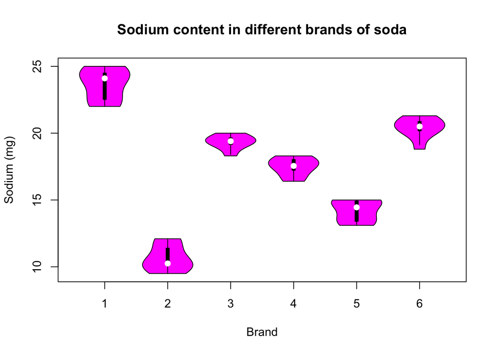

```r
vioplot(pop$Sodium[pop$Brand == 1],
        pop$Sodium[pop$Brand == 2],
        pop$Sodium[pop$Brand == 3],
        pop$Sodium[pop$Brand == 4],
        pop$Sodium[pop$Brand == 5],
        pop$Sodium[pop$Brand == 6])
title(main = "Sodium content in different brands of soda",
     ylab = "Sodium (mg)", xlab = "Brand")
```

## 25.7.b

```r
pop.u = mean(pop$Sodium)
pop.n = sum(pop$Brand == 1) # balanced so counting == 1 is counting for all i
pop.r = length(unique(pop$Brand))
pop.alpha = 0.01
pop.t = qt(1-pop.alpha/2, pop.r-1)

pop.sstr = pop.n*sum((pop.us$Sodium - pop.u)^2)
pop.mstr = pop.sstr/(pop.r-1)

pop.sse = sum((pop.u-pop$Sodium)^2)
pop.mse = pop.sse/(pop.r*(pop.n-1))

pop.ybar.s2 = pop.mstr/(pop.n*pop.r)
pop.99ci = pop.t * sqrt(pop.ybar.s2)
```

The mean sodium content for all brands of soda is $17.6291667\pm7.6084072$ mg sodium.

# 25.8

## 25.8.a

```r
pop.alpha = 0.01
pop.s2u = (pop.mstr-pop.mse)/pop.n
pop.s2 = pop.mse
pop.rats2 = pop.s2u/(pop.s2u + pop.s2) # point estimate

pop.fs = pop.mstr/pop.mse
pop.f.l.denom = qf(1-pop.alpha/2, pop.r-1, pop.r*(pop.n-1))
pop.f.u.denom = qf(pop.alpha/2, pop.r-1, pop.r*(pop.n-1))
pop.L = (1/pop.n)*(pop.fs / (pop.f.l.denom) - 1)
pop.U = (1/pop.n)*(pop.fs / (pop.f.u.denom) - 1)
pop.Ls = pop.L/(pop.L+1) # lower and upper confidence intervals
pop.Us = pop.U/(pop.U+1)
```

$\frac{\sigma^2_\mu}{\sigma^2_\mu+\sigma^2}$ is estimated by $\frac{s^2_\mu}{s^2_\mu+s^2}=0.4707056$ with a $1-\alpha=0.99$% confidence interval of $(L,U)=(0.1162979,0.9262844)$.

## 25.8.c

```r
pop.alpha = 0.01
pop.s2.ci.X2 = (pop.r*(pop.n-1)*pop.mse)
pop.s2.ci.X2.df = pop.r*(pop.n-1)
pop.s2.ci.low = pop.s2.ci.X2/qchisq(1-pop.alpha/2, pop.s2.ci.X2.df)
pop.s2.ci.hi = pop.s2.ci.X2/qchisq(pop.alpha/2, pop.s2.ci.X2.df)
```

The $1-\alpha=0.99$ confidence interval for $\sigma^2$ is $(L,U)=(12.7581516, 39.9575686)$.

## 25.8.d

The hypothesis being tested is $H_a:\frac{\sigma^2_\mu}{\sigma^2}>2$. The $99$% confidence interval for the quantity being tested is $(L,U)=(0.1316031, 12.5656479)$. This confidence interval contains values smaller than $2$ so we fail to reject the complementary hypothesis that the quantity is less than $2$. That is, we can’t be sure that the variability in sodium levels between brands is at least twice the variability within brands.

## 25.8.e

```r
pop.alpha = 0.01
pop.s2u = (pop.mstr-pop.mse)/pop.n
pop.satter.df =
    (pop.n*pop.s2u)^2/((pop.mstr^2)/(pop.r-1)+(pop.mse^2)/(pop.r*(pop.n-1)))
pop.satter.df = ceiling(pop.satter.df)
pop.s2u.low = pop.satter.df*pop.s2u/qchisq(1-pop.alpha/2, pop.satter.df)
pop.s2u.hi = pop.satter.df*pop.s2u/qchisq(pop.alpha/2, pop.satter.df)
```

The Satterthwaite $1-\alpha=0.99$ confidence interval for $\sigma^2_\mu$ is $(L,U)=(5.0417677, 361.9609755)$. This is clearly a pretty big confidence interval, so it doesn’t give us much information on the absolute value of $\sigma^2_\mu$, but we can conclude with high certianty that $\sigma^2_\mu\ne 0$.

# 25.16

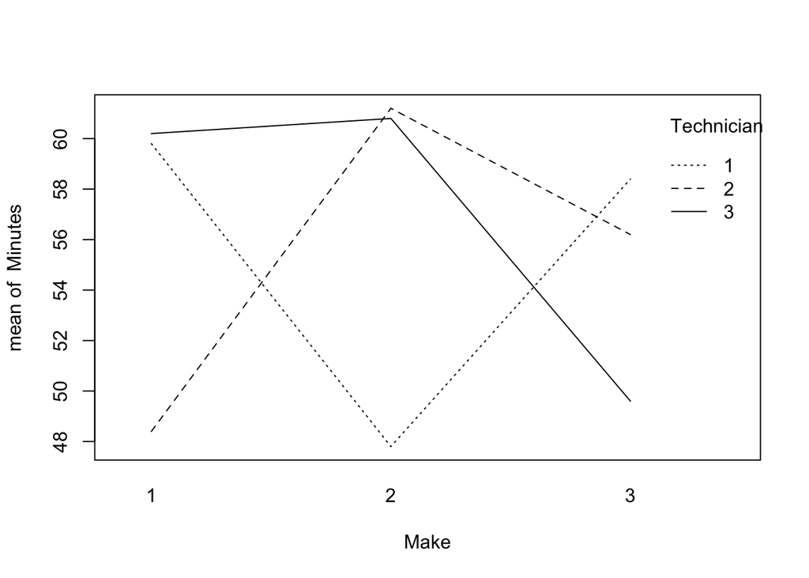

```r
dsk = read.csv("disks.csv")
dsk$Technician = as.factor(dsk$Technician)
dsk$Make = as.factor(dsk$Make)
with(dsk, interaction.plot(Make, Technician, Minutes))
```

## 25.16.a

Using ANOVA III, we test for interaction effects with an F test. If the emperical F statistic is larger than the corresponding theoretical F statistic for the specified confidence level, we reject the null hypothesis that there are no interactions. Otherwise, we fail to reject the null hypothesis.

```r
dsk.alpha = 0.01
dsk.a = length(unique(dsk$Make)) # Fixed make aka factor A, i=1..a
dsk.b = length(unique(dsk$Technician)) # Random tech aka factor B, j=1..b
dsk.n = dim(dsk)[1]/(dsk.a*dsk.b) # balanced model

dsk.anova = with(dsk, anova(aov(Minutes ~ Technician*Make)))
dsk.sse = dsk.anova["Residuals", "Sum Sq"]
dsk.mse = dsk.sse/((dsk.n-1)*(dsk.a*dsk.b))
dsk.ssab = dsk.anova["Technician:Make", "Sum Sq"]
dsk.msab = dsk.ssab/((dsk.a-1)*(dsk.b-1))

dsk.fe = dsk.msab/dsk.mse # emperical f value
dsk.ft = qf(1-dsk.alpha, (dsk.a-1)*(dsk.b-1), (dsk.n-1)*dsk.a*dsk.b)
dsk.p = 1-pf(dsk.fe, (dsk.a-1)*(dsk.b-1), (dsk.n-1)*dsk.a*dsk.b)
```

$F^*=5.8414869>F^{\alpha=0.01}=3.8903083$ so we reject the null hypothesis that there are no interactions with $p=9.9410684\times 10^{-4}$.

## 25.16.b

```r
dsk.s2 = dsk.mse
dsk.s2ab = (dsk.msab-dsk.mse)/dsk.n
```

$\sigma^2=52.0111111$ and $\sigma^2_{\alpha\beta}=50.3622222$. The interaction variation accounts for a large proportion $(\frac{\sigma^2_{\alpha\beta}}{\sigma^2}=0.9682974)$ of the variation in this sample. This could be because each technician specializes in a particular make, even though they have equal training time on each.

## 25.16.c

To test for technician effects, we utilize the random effects test because subjects were selected randomly.

```r
dsk.ssa =  dsk.anova["Technician", "Sum Sq"]
dsk.msa = dsk.ssa/(dsk.a-1)
dsk.fe = dsk.msa/dsk.msab
dsk.ft = qf(1-dsk.alpha, dsk.a-1, (dsk.a-1)*(dsk.b-1))
```

The emperical $F^*=0.0404476<F^{\alpha=0.01}=18$ so we fail to reject the null hypothesis that $\alpha_i=0$ for all $i\in\{1\dots a\}$.

## 25.16.d

To test for make effects, we utilize the fixed effects test because makes are selected purposely. Hence we will compare $MSB$ to $MSE$ rather than $MSAB$ as in the random factor test.

```r
dsk.ssb =  dsk.anova["Make", "Sum Sq"]
dsk.msb = dsk.ssb/(dsk.b-1)
dsk.fe = dsk.msb/dsk.mse
dsk.ft = qf(1-dsk.alpha, dsk.b-1, (dsk.n-1)*dsk.a*dsk.b)
```

The emperical $F^*=0.2721641<F^{\alpha=0.01}=5.247894$ so we fail to reject the null hypothesis that $\beta_j=0$ for all $j\in\{1\dots b\}$.

## 25.16.e

```r
dsk.alpha = 0.05
dsk.us = with(dsk, aggregate(Minutes, list(Make), mean))
dsk.tuk.s2 = 2*dsk.mse/(dsk.n*dsk.b)
dsk.tuk.t = (1/sqrt(2))*qtukey(1-dsk.alpha, 3, (dsk.n-1)*dsk.a*dsk.b)
dsk.tuk.m = sqrt(dsk.tuk.s2)*dsk.tuk.t

dsk.D1 = dsk.us$x[1] - dsk.us$x[2]
dsk.D2 = dsk.us$x[1] - dsk.us$x[3]
dsk.D3 = dsk.us$x[2] - dsk.us$x[3]
```

## 25.16.f

```r
dsk.alpha = 0.01
dsk.ud1 = dsk.us$x[1]
dsk.sat.df = ((dsk.a-1)/(dsk.n*dsk.a*dsk.b)*dsk.msab +
            1/(dsk.n*dsk.a*dsk.b)*dsk.msb)^2 / (
            ((dsk.a-1)/(dsk.n*dsk.a*dsk.b)*dsk.msab)^2/((dsk.a-1)*(dsk.b-1)) +
            (1/(dsk.n*dsk.a*dsk.b)*dsk.msb)^2/(dsk.b-1))
dsk.ud1.s2 = (dsk.a-1)/(dsk.n*dsk.a*dsk.b)*dsk.msab +
    1/(dsk.n*dsk.a*dsk.b)*dsk.msb
dsk.ud1.m = qt(1-dsk.alpha/2, dsk.sat.df) * sqrt(dsk.ud1.s2)
```